# Lecture 04 Part 3

Statistics 422

# Interactivity

## Briefly

- Want to publish web-based reports with dynamic features (tooltips, zoom, filtering)?
- Want to build dashboards or data apps ?
- Need to present exploratory data analysis interactively?
- Work in places where user engagement with data is important?
- Perhaps invest time working with interactive tools

## Some stats

[output not shown]

# Visualizations with dynamic features

## Plotly

- Interactive scatterplots, bar charts, and time series
- 3D charts (scatter, surface)
- Geographic visualizations (choropleths, maps)
- Works well with Python (e.g. pandas) retiring support for R
- In Python start with plotly express https://plotly.com/python/plotly-express/ (Python built on plotly)

## Basic Python Example using plotly express

- Code
- Viz

```python
import pandas as pd
import plotly.express as px

AAPL10 = pd.read_csv("AAPL10p.csv")

## create date/year/month variables as datetime
AAPL10['Date'] = pd.to_datetime(AAPL10['Date'], format='%m/%d/%Y')
AAPL10['Year'] = AAPL10['Date'].dt.year
AAPL10['Month'] = AAPL10['Date'].dt.month

## fix the Close and Low
AAPL10[['Close', 'Low']] = AAPL10[['Close/Last', 'Low']].replace(r'[\$,]', '', regex=True).astype(float)

# drop unused columns (axis = 1)
AAPL10 = AAPL10.drop(['Close/Last', 'Date'], axis = 1)

# Creates 2015-05-01, 2015-06-01 etc
AAPL10['Date'] = pd.to_datetime(AAPL10[['Year', 'Month']].assign(DAY=1))

## Sort the data (important if it's not already sorted), get rid of old index
AAPL10 = AAPL10.sort_values('Date').reset_index(drop=True)

## plotly offers some simplicity
fig = px.line(AAPL10, x='Year', y='Close', line_shape='spline')
fig.show()
```

[interactive chart not shown]

## Plotly with melt instead

- Data Code
- Data
- Viz Code
- Viz

```python
# import pandas as pd
# import plotly.express as px

# Load and clean
AAPL10 = pd.read_csv("AAPL10p.csv")
AAPL10['Date'] = pd.to_datetime(AAPL10['Date'], format='%m/%d/%Y')
AAPL10 = AAPL10[AAPL10['Date'] > '2019/12/31']

AAPL10['Year'] = AAPL10['Date'].dt.year
AAPL10['Month'] = AAPL10['Date'].dt.month

# Clean and convert price columns
AAPL10[['Close', 'Low', 'High']] = AAPL10[['Close/Last', 'Low', 'High']].replace(r'[\$,]', '', regex=True).astype(float)
AAPL10 = AAPL10.drop(['Close/Last', 'Date'], axis=1)

# Create a monthly date
AAPL10['Date'] = pd.to_datetime(AAPL10[['Year', 'Month']].assign(DAY=1))

# Make sure it is sorted correctly
AAPL10 = AAPL10.sort_values('Date').reset_index(drop=True)

# Melt the data to long format for multiline plotting
df_long = AAPL10.melt(id_vars='Date', value_vars=['Close', 'Low', 'High'],
                      var_name='PriceType', value_name='Price')
```

```python
df_long
```

```
           Date PriceType     Price
0    2020-01-01     Close   75.0875
1    2020-01-01     Close   77.3775
2    2020-01-01     Close   80.9675
3    2020-01-01     Close   81.0850
4    2020-01-01     Close   79.4225
...         ...       ...       ...
4024 2025-04-01      High  203.5100
4025 2025-05-01      High  214.5600
4026 2025-05-01      High  206.9900
4027 2025-05-01      High  204.1000
4028 2025-05-01      High  200.6500

[4029 rows x 3 columns]
```

```python
fig = px.line(df_long, x='Date', y='Price', color='PriceType',
              title='AAPL Prices Over Time',
              labels={'Price': 'Price (USD)', 'Date': 'Date', 'PriceType': 'Price Type'})
```

```python
fig.show()
```

[interactive chart not shown]

## Streamlit

- https://streamlit.io/ Is small and fast and a nice way to showcase your data science skills (not for big companies)
- It works nicely with plotly and other Python libraries
- Streamlit is like Shiny in R, easy to use with a client-server structure.
- Python is the server. The frontend, in a browser, is the client.

## Plotly express + streamlit

- Code
- Terminal
- Result

```python
## Not run, needs to be run from a script (.py) this one is px_sl.py
# run at prompt with streamlit run px_sl.py
import pandas as pd
import streamlit as st
import plotly.express as px
from sklearn.datasets import load_iris

# Load and convert to DataFrame
iris = load_iris()
df = pd.DataFrame(iris.data, columns=iris.feature_names)
df['species'] = pd.Categorical.from_codes(iris.target, iris.target_names)

# Create a Plotly Express figure
fig = px.scatter(
    data_frame=df,
    x="sepal width (cm)",
    y="sepal length (cm)",
    color="species",
    title="Iris Flower Scatterplot"
)

# Display it in Streamlit
st.plotly_chart(fig)
```

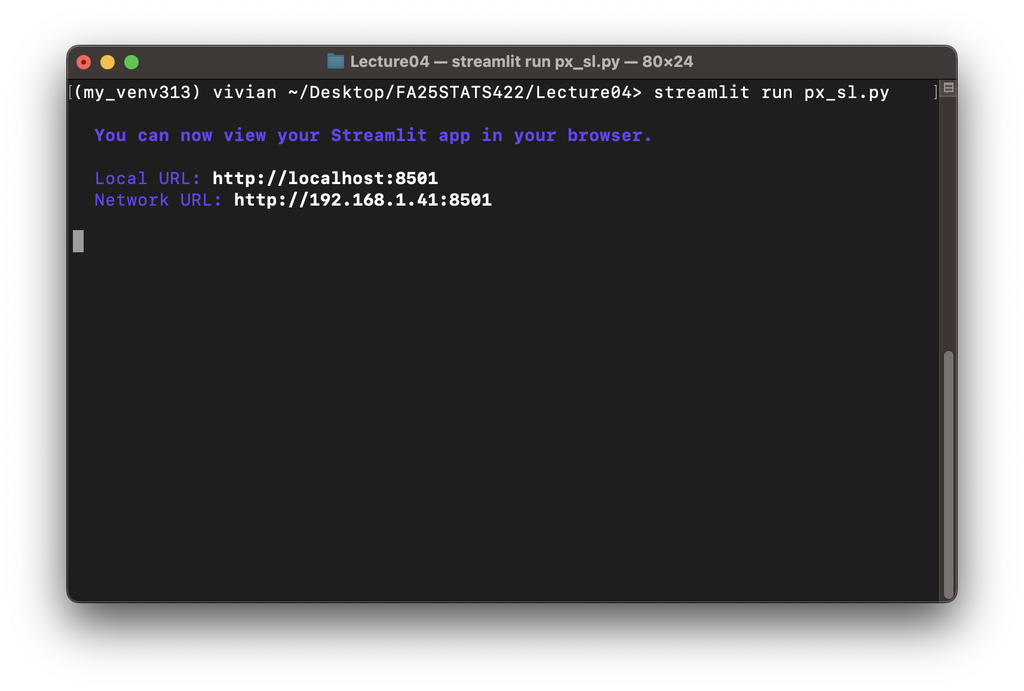

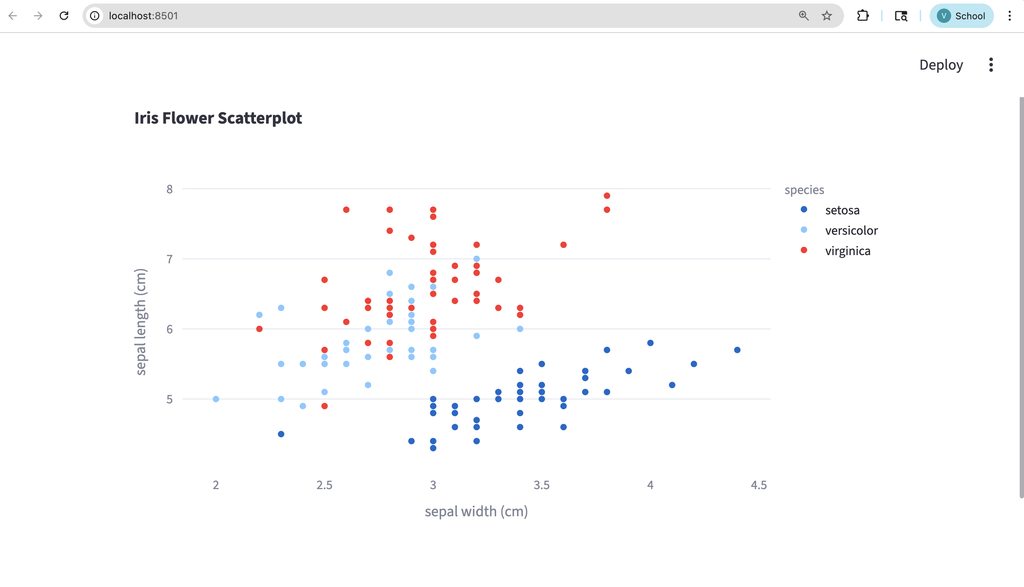

## Plotly express + streamlit (extra)

You can see an earthquake page evolve using streamlit:

- [streamlitEQ1.py](https://ucla.box.com/s/iwc5twkotwt1exkf6oensizn8nen0pbh)
- [streamlitEQ2.py](https://ucla.box.com/s/3tbp1kxes9eqpi7kom0lroo7t4la9grs)
- [streamlitEQ3.py](https://ucla.box.com/s/uv0u7fnt7rrqbissc0e1z9vfoilxsb17)

These can be downloaded then run in terminal (will work in VSCode terminal) or cmd/Powershell using

- streamlit run streamlitEQn.py where n is 1, 2 or 3

## Earthquake Example 1

- streamlitEQ1
- Result1
- Result2

```python
"""
INTRO: This is my little streamlit app using earthquake data from CalTech
It will update every time you run it

TO RUN: streamlit run streamlitEQ.py
"""

import streamlit as st
import pandas as pd
import plotly.express as px


## Load the dataset from the web
url = "https://service.scedc.caltech.edu/ftp/catalogs/SCEC_DC/2025.catalog"
column_names = ["YMD", "HMS", "ET", "GL", "MAG", "M" ,"LAT", "LON", "DEPTH", "Q",  "EVID" , "NPH", "RMS"]

df = pd.read_csv(url, names=column_names, skiprows=10, sep=r'\s+')
df = df[:-1]  # Removes the final row

## Combine YMD and HMS into one datetime string
df['DateTimeStr'] = df['YMD'].astype(str) + ' ' + df['HMS'].astype(str)

# Parse it into a proper datetime object
df['DateTime'] = pd.to_datetime(df['DateTimeStr'], format='%Y/%m/%d %H:%M:%S.%f',
    errors='coerce'
    )

## Drop stuff
df = df.dropna(subset=['DateTime'])
df = df.drop(columns=['YMD', 'HMS', 'DateTimeStr'])

## Reorder the columns
cols = ['DateTime'] + [col for col in df.columns if col != 'DateTime']
df = df[cols]

## Sort newest for display
df = df.sort_values('DateTime', ascending=False)

## Display the dataset in Streamlit
st.dataframe(df, hide_index=True)

## Histogram in Plotly
hist_fig = px.histogram(df, x="DEPTH")

st.plotly_chart(hist_fig, use_container_width=True)
```

[figure not shown]

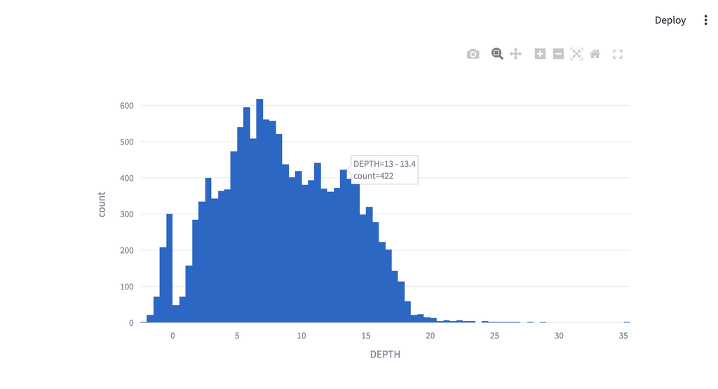

## Earthquake Example 2

- streamlitEQ2
- Result

```python
"""
INTRO: This upgraded streamlit app uses a sidebar

TO RUN: streamlit run streamlitEQ2.py
"""

import streamlit as st
import pandas as pd
import plotly.express as px

# App title
st.title("Earthquake Explorer – SCEC 2025 Catalog")

# Load dataset
url = "https://service.scedc.caltech.edu/ftp/catalogs/SCEC_DC/2025.catalog"
column_names = ["YMD", "HMS", "ET", "GL", "MAG", "M" ,"LAT", "LON", "DEPTH", "Q",  "EVID" , "NPH", "RMS"]

df = pd.read_csv(url, names=column_names, skiprows=10, sep=r'\s+')
df = df[:-1]  # Drop final malformed row

# Clean and process data
df['MAG'] = df['MAG'].astype(float)
df['DateTimeStr'] = df['YMD'].astype(str) + ' ' + df['HMS'].astype(str)
df['DateTime'] = pd.to_datetime(df['DateTimeStr'], format='%Y/%m/%d %H:%M:%S.%f', errors='coerce')
df = df.dropna(subset=['DateTime'])
df = df.drop(columns=['YMD', 'HMS', 'DateTimeStr'])

# Reorder and sort
cols = ['DateTime'] + [col for col in df.columns if col != 'DateTime']
df = df[cols]
df = df.sort_values('DateTime', ascending=False)

# --- Sidebar: Date Filter ---
st.sidebar.header("Filter by Date Range")
min_date = df['DateTime'].min().date()
max_date = df['DateTime'].max().date()
start_date, end_date = st.sidebar.date_input(
    label="Select range:",
    value=[min_date, max_date],
    min_value=min_date,
    max_value=max_date
)

# --- Sidebar: Magnitude Filter ---
st.sidebar.header("Filter by Magnitude")
min_mag = df['MAG'].min()
max_mag = df['MAG'].max()
mini_mag, maxi_mag = st.sidebar.slider(
    label="Select range:",
    value=[min_mag, max_mag],
    min_value=min_mag,
    max_value=max_mag
)

# Filter by date and magnitude
filtered_df = df[
    (df['DateTime'].dt.date >= start_date) &
    (df['DateTime'].dt.date <= end_date) &
    (df['MAG'] >= mini_mag) &
    (df['MAG'] <= maxi_mag)
]

# Data Table
st.header(":blue[Earthquake Data Table] :sunglasses:")
st.dataframe(filtered_df, hide_index=True)
st.divider()

# Map Plot
map_fig = px.scatter_map(
    filtered_df,
    lat='LAT',
    lon='LON',
    color='MAG',
    size='MAG',
    hover_name='DateTime',
    zoom=6,
    height=500,
    title=f"Earthquakes from {start_date} to {end_date} with Magnitude {mini_mag}–{maxi_mag}"
)
map_fig.update_layout(mapbox_style='open-street-map')
map_fig.update_layout(margin={"r":0,"t":30,"l":0,"b":0})

st.header(":smile: :blue[Earthquake Map]")
st.subheader("using plotly and open street map", divider="gray")
st.plotly_chart(map_fig, use_container_width=True)
st.markdown("<br><br><br>", unsafe_allow_html=True)

# Depth Histogram
hist_fig = px.histogram(filtered_df, x="DEPTH")

st.header(":blue[Distribution of Depth] $d = \\frac{(v * t)}{2}$ ")
st.plotly_chart(hist_fig, use_container_width=True)
st.divider()

# Bar Plot
q_df = filtered_df['Q'].value_counts().reset_index()
q_df.columns = ['Q', 'count']
q_df = q_df.sort_values('Q')

fig = px.bar(q_df,
             x='Q',
             y='count',
             color='Q',
             title='Frequency of Quality Codes (Q)',
             labels={'Q': 'Quality Code', 'count': 'Frequency'},
             height=400)
fig.update_layout(xaxis=dict(type='category'), bargap=0.2)

st.header(":small[Quality Code Frequency where A = high]")
st.plotly_chart(fig, use_container_width=True)

st.image("http://www.stat.ucla.edu/~vlew/harry_xmas.jpeg", caption="Harry Xmas")
```

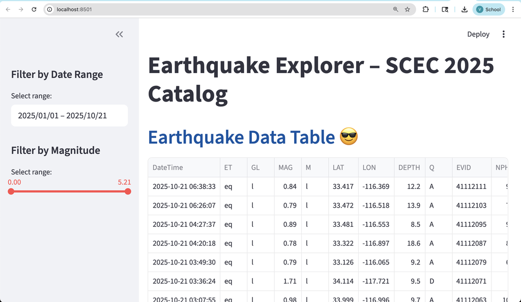

## Earthquake Example 3

- streamlitEQ3
- Result

```python
"""
INTRO: This upgraded streamlit app uses a sidebar, tabs
       and Multiple Years of Data

TO RUN: streamlit run streamlitEQ3.py
"""

import streamlit as st
import pandas as pd
import plotly.express as px

## Sidebar: Year Selector
st.sidebar.header("Select Catalog Year")
years_available = [2025, 2024, 2023, 2022, 2021, 2020]
selected_year = st.sidebar.selectbox("Year:", years_available, index=0) # set to 2025 index = 0

## App title
st.title(f"Earthquake Explorer – SCEC {selected_year} Catalog")


## Build URL based on selected_year
url = f"https://service.scedc.caltech.edu/ftp/catalogs/SCEC_DC/{selected_year}.catalog"


## Load dataset using url
column_names = ["YMD", "HMS", "ET", "GL", "MAG", "M" ,"LAT", "LON", "DEPTH", "Q",  "EVID" , "NPH", "RMS"]
df = pd.read_csv(url, names=column_names, skiprows=10, sep=r'\s+')
df = df[:-1]  # Drop final malformed row

## Clean and process data
df['MAG'] = df['MAG'].astype(float)
df['DateTimeStr'] = df['YMD'].astype(str) + ' ' + df['HMS'].astype(str)
df['DateTime'] = pd.to_datetime(df['DateTimeStr'], format='%Y/%m/%d %H:%M:%S.%f', errors='coerce')
df = df.dropna(subset=['DateTime'])
df = df.drop(columns=['YMD', 'HMS', 'DateTimeStr'])

## Reorder and sort data
cols = ['DateTime'] + [col for col in df.columns if col != 'DateTime']
df = df[cols]
df = df.sort_values('DateTime', ascending=False)

## --- Sidebar: Date Filter ---
st.sidebar.header("Filter by Date Range")
min_date = df['DateTime'].min().date()
max_date = df['DateTime'].max().date()
start_date, end_date = st.sidebar.date_input(
    label="Select range:",
    value=[min_date, max_date],
    min_value=min_date,
    max_value=max_date
)

## --- Sidebar: Magnitude Filter ---
st.sidebar.header("Filter by Magnitude")
min_mag = df['MAG'].min()
max_mag = df['MAG'].max()
mini_mag, maxi_mag = st.sidebar.slider(
    label="Select range:",
    value=[min_mag, max_mag],
    min_value=min_mag,
    max_value=max_mag
)

## Filter by date and magnitude
filtered_df = df[
    (df['DateTime'].dt.date >= start_date) &
    (df['DateTime'].dt.date <= end_date) &
    (df['MAG'] >= mini_mag) &
    (df['MAG'] <= maxi_mag)
]

## Map Plot
map_fig = px.scatter_map(
    filtered_df,
    lat='LAT',
    lon='LON',
    color='MAG',
    size='MAG',
    hover_name='DateTime',
    zoom=6,
    height=500,
    title=f"Earthquakes from {start_date} to {end_date} with Magnitude {mini_mag}–{maxi_mag}"
)
map_fig.update_layout(mapbox_style='open-street-map')
map_fig.update_layout(margin={"r":0,"t":30,"l":0,"b":0})

## Depth Histogram
hist_fig = px.histogram(filtered_df, x="DEPTH", marginal='box', opacity=0.4)

## Bar Plot
q_df = filtered_df['Q'].value_counts().reset_index()
q_df.columns = ['Q', 'count']
q_df = q_df.sort_values('Q')

fig = px.bar(q_df,
             x='Q',
             y='count',
             color='Q',
             title='Frequency of Quality Codes (Q)',
             labels={'Q': 'Quality Code', 'count': 'Frequency'},
             height=400)
fig.update_layout(xaxis=dict(type='category'), bargap=0.2)


## Using tabs to avoid scrolling
tab1, tab2, tab3, tab4  = st.tabs(["Map", "Histogram", "Bar Chart", "Table"])

with tab1:
    st.markdown('## Earthquake Map')
    st.plotly_chart(map_fig, use_container_width=True)

with tab2:
    st.markdown('## Distribution of Depth')
    st.plotly_chart(hist_fig, use_container_width=True)

with tab3:
    st.markdown('## Quality Code Bar Plot')
    st.plotly_chart(fig, use_container_width=True)

with tab4:
    st.markdown('## Earthquake Data Table')
    st.dataframe(filtered_df, hide_index=True)
```

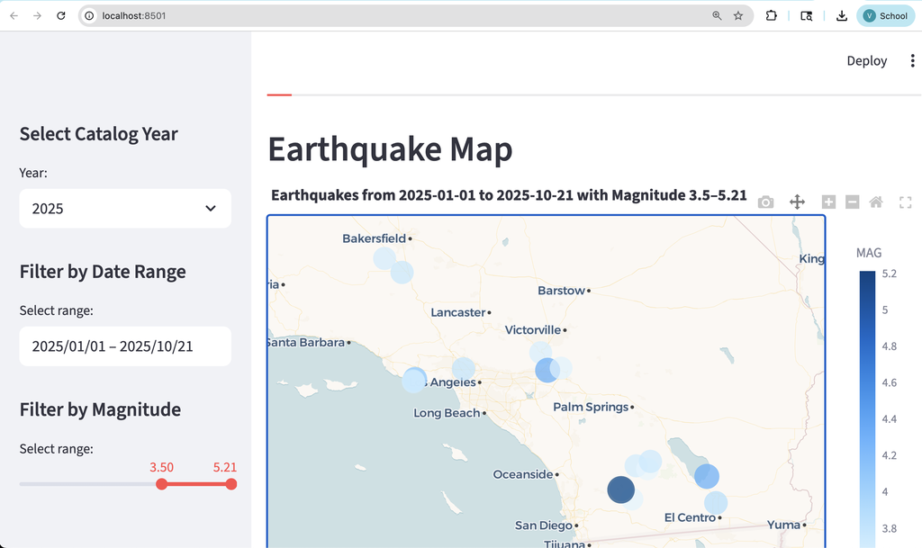

# DataViz Principles Reminderss

## Basic Types

| Purpose | Suggested Type | Data Requirements |
| --- | --- | --- |
| Compare categories (simple) | **Bar chart** | Categorical x-axis, numerical y-axis |
| Compare parts of a whole | **Stacked bar**, **Pie chart** (only 1 category!) | Percentages/sums that total to 100% |
| Compare over time (few categories) | **Line chart**, **Grouped bar** | Time series + categories |
| Show distribution of one variable | **Histogram**, **Density plot** | Numerical variable |
| Compare distributions | **Boxplot**, **Violin plot** | One numeric + one categorical |
| See outliers or variation | **Boxplot** | same |

## Basic Types cont’d

| Purpose | Suggested Type | Data Requirements |
| --- | --- | --- |
| Show trend over time (one series) | **Line chart**, **Area chart** | Time on x-axis, numeric y-axis |
| Multiple trends over time | **Multiple line chart**, **Facets** | One series per group/category |
| Relate Two numeric variables | **Scatterplot**, **Bubble chart** | 2+ numeric variables |
| Clusters or group differences | **Scatterplot with color/shape by group** | Group + 2 numeric variables |

## Using Color

- Color is a highly effective way to communicate information and highlight specific elements within a visualization.
- Color > Shape
- Large numbers of observations should be summarized
- Combining color, shape, size, texture, can be tricky opacity

## Shape

[Article (optional) by Heer & Bostock](http://vis.stanford.edu/files/2010-MTurk-CHI.pdf)

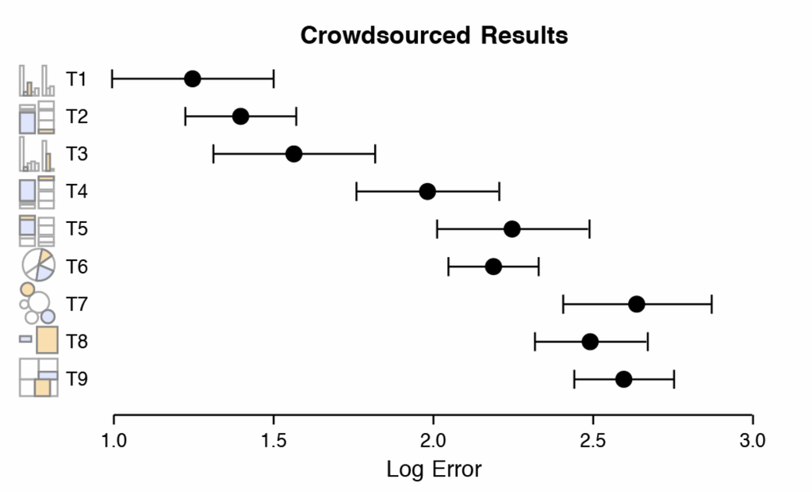